# 多元统计分析--理论与代码总结

## 5. 聚类分析

> 聚类的目的是找到一个类别内部差异小而类别间差异大的一种分割方式

### 5.1 距离衡量方式

测算两点之间的距离总的来说有两种方法：一个是计算距离、另一个是使用相关系数代表距离。

- Manhattan距离(绝对值距离):
  $$d_{ij}(1)=\sum_{k=1}^p\mid x_{ik}-x_{jk} \mid$$
- Euclidean距离(欧氏距离):
  $$d_{ij}(2)=\bigg[\sum_{k=1}^p(x_{ik}-x_{jk})^2\bigg]^{\frac{1}{2}}$$
- Minkowski距离(明考斯基距离): $$d_{ij}(q)=\bigg[\sum_{k=1}^p(x_{ik}-x_{jk})^q\bigg]^{\frac{1}{q}}, \quad (q > 0)$$
- maxmin距离(切比雪夫距离): $$d_{ij}(\infty)=\max_{1\le k\le p}\mid x_{ik}-x_{jk}\mid$$
- 马氏距离: 马氏距离使用协方差矩阵(S)，修正了欧式距离中各个维度尺度不一致且相关的问题，可以视为对欧氏距离的补充 $$d_{ij}(M)=\acute{(X_{(i)}-X_{(j)})}S^(-1)(X_{(i)}-X_{(j)})$$
- canberra(兰氏距离): 这个距离克服了量纲的影响，但没有考虑指标间的相关性。 $$d_{ij}(L)=\frac{1}{p}\sum_{k=1}^p\frac{\mid x_{ik}-x_{jk}\mid}{x_{ik}+x_{jk}}, \quad (x_{ij}>0)$$

计算距离要考虑两点：一个是上面提到的测算距离的方式，另一个是衡量两类之间距离的方法。

[figure not shown]

### 5.2 系统聚类

系统聚类首先将每个观测作为一个类，计算每类之间的距离，之后合并距离最近的两个类，然后重新计算距离，直到最后合并成一个类。之后可以向后推导找到我们想要的分为n个类别的情况。  
有一个问题就是：选择一个什么样的类别数量是合适的？  
一般我们有三种方法确定类别数量：给定类别间距离的阈值、观察散点图、使用统计量、根据谱系图确定分类个数的准确。

### 5.3 kmeans聚类

动态聚类又称为逐步聚类法，其基本思想是，开始先粗略地分一下类，然后按照某种最有原则修改不合理的分类，直至类分得比较合理为止，这样就形成一个最终的分类结果。这种方法具有计算量较小，占计算机内存较少和方法简单的优点。比较典型的动态聚类的一个方法是k-means聚类法，在r语言中采用kmeans()函数。  
k-means算法的具体**工作流程**如下：

- step1：导入一组具有n个对象的数据集，给出聚类个数k；
- step2：从n个对象中随机取出k个作为初始聚类中心；
- step3：根据欧几里得距离来判断相似度量，确定每个对象数据哪个簇；
- step4：计算并更新每个簇中对象的平均值，并将其定为每个簇的新的聚类中心；
- step5：计算出准则函数E；
- step6：循环step3，step4，step5直到准则函数E在允许的误差范围内

> 可以总结为以下的步骤：构筑起始点，将所有点分类到不同类中，重新计算中心位置，再对所有点进行分类，直到稳定，也可以限定分类次数

**特征:**

- 发现球形互斥的簇：由于K-means算法一般是以欧几里得距离作为相似性度量指标，所以K-means算法对于球形互斥的簇的聚类效果会比较好；
- 对低维数据集效果较好：同样的数据量，维度越高，数据矩阵越稀疏，当数据维度比较高时，数据矩阵是一个稀疏矩阵，K-means算法稀疏矩阵数据聚类效果不佳；
- 容易陷入局部最优：对于K-means算法来说，初始聚类中心的确定十分重要，因为不同的聚类中心会使算法沿着不同的路径搜索最优聚类结果，不过对于陷入局部最优这个问题可以从初始聚类中心的选择来进行改进。  
  **函数解释：**

  ```
  {r}
  kmeans(x, centers, iter.max=10, nstart=1, algorithm=c("Hartigan-Wong", "Lloyd", "Forgy", "MacQueen"), trace=FALSE)
  ```

  其中x是由数据构成的矩阵或数据框，centers是聚类的个数或者是初始类的中心。iter.max为最大迭代次数。nstart随机集合的个数（当centers为聚类的个数时）。algorithm为动态聚类的算法，缺省值为Hartigan-Wong方法。

```r
X_1758 <- data.frame(x1=c(2959.19, 2459.77, 1495.63, 1046.33, 1303.97, 1730.84, 1561.86, 1410.11, 3712.31, 2207.58, 2629.16, 1844.78, 2709.46, 1563.78, 1675.75, 1427.65, 1783.43, 1942.23, 3055.17, 2033.87, 2057.86, 2303.29, 1974.28, 1673.82, 2194.25, 2646.61, 1472.95, 1525.57, 1654.69, 1375.46, 1608.82),
                x2=c(730.79, 495.47, 515.90, 477.77, 524.29, 553.90, 492.42, 510.71, 550.74, 449.37, 557.32, 430.29, 428.11, 303.65, 613.32, 431.79, 511.88, 512.27, 353.23, 300.82, 186.44, 589.99, 507.76, 437.75, 537.01, 839.70, 390.89, 472.98, 437.77, 480.99, 536.05),
                x3=c(749.41, 697.33, 362.37, 290.15, 254.83, 246.91, 200.49, 211.88, 893.37, 572.40, 689.73, 271.28, 334.12, 233.81, 550.71, 288.55, 282.84, 401.39, 564.56, 338.65, 202.72, 516.21, 344.79, 461.61, 369.07, 204.44, 447.95, 328.90, 258.78, 273.84, 432.46),
                x4=c(513.34, 302.87, 285.32, 208.57, 192.17, 279.81, 218.36, 277.11, 346.93, 211.92, 435.69, 126.33, 160.77, 107.90, 219.79, 208.14, 201.01, 206.06, 356.27, 157.78, 171.79, 236.55, 203.21, 153.32, 249.54, 209.11, 259.51, 219.86, 303.00, 317.32, 235.82),
                x5=c(467.87, 284.19, 272.95, 201.50, 249.81, 239.18, 220.69, 224.65, 527.00, 302.09, 514.66, 250.56, 405.14, 209.70, 272.59, 217.00, 237.60, 321.29, 811.88, 329.06, 329.65, 403.92, 240.24, 254.66, 290.84, 379.30, 230.61, 206.65, 244.93, 251.08, 250.28),
                x6=c(1141.82, 735.97, 540.58, 414.72, 463.09, 445.20, 459.62, 376.82, 1034.98, 585.23, 795.87, 513.18, 461.67, 393.99, 599.43, 337.76, 617.74, 697.22, 873.06, 621.74, 477.17, 730.05, 575.10, 445.59, 561.91, 371.04, 490.90, 449.69, 479.53, 424.75, 541.30),
                x7=c(478.42, 570.84, 364.91, 281.84, 287.87, 330.24, 360.48,317.61, 720.33, 429.77, 575.76, 314.00, 535.13, 509.39, 371.62, 421.31, 523.52, 492.60, 1082.82, 587.02, 312.93, 438.41, 430.36, 346.11, 407.70, 269.59, 469.10, 249.66, 288.56, 228.73, 344.85),
                x8=c(457.64, 305.08, 188.63, 212.10, 192.96, 163.86, 147.76, 152.85, 462.03, 252.54, 323.36, 151.39, 232.29, 160.12, 211.84, 165.32, 182.52, 226.45, 420.81, 218.27, 279.19, 225.80, 223.46, 191.48, 330.95, 389.33, 191.34, 228.19, 236.51, 195.93, 214.40),
                row.names=c("北京","天津","河北","山西","内蒙古","辽宁","吉林","黑龙江","上海","江苏","浙江","安徽","福建","江西","山东","河南","湖北","湖南","广东","广西","海南","重庆","四川","贵州","云南","西藏","陕西","甘肃","青海","宁夏","新疆"))
```

```r
# 计算距离矩阵
x <- c(1, 2, 4.5, 6, 8)
# 转换为列向量，一维向量也可以计算距离矩阵
dim(x) <- c(5, 1)
# upper=是否展示上三角、diag=是否展示对角线、method=使用什么方式计算距离
dist(x, upper=T, diag=T, method="manhattan")
```

```
    1   2   3   4   5
1 0.0 1.0 3.5 5.0 7.0
2 1.0 0.0 2.5 4.0 6.0
3 3.5 2.5 0.0 1.5 3.5
4 5.0 4.0 1.5 0.0 2.0
5 7.0 6.0 3.5 2.0 0.0
```

```r
# 使用距离计算方式进行聚类
d <- dist(x)
hc1 <- hclust(d, 'single')
hc2 <- hclust(d, 'complete')
hc3 <- hclust(d, 'median')
hc4 <- hclust(d, 'ward.D')
```

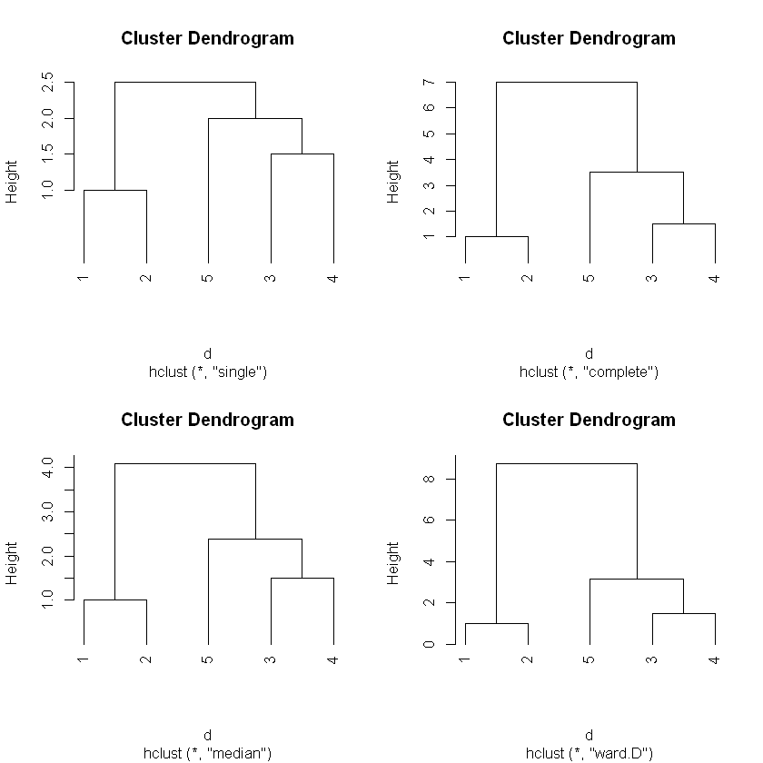

```r
# 绘制聚类结果，参数hang=-1保证每个观测都在一条基准线上
opar <- par(mfrow=c(2,2))
plot(hc1, hang=-1)
plot(hc2, hang=-1)
plot(hc3, hang=-1)
plot(hc4, hang=-1)
par(opar)
```

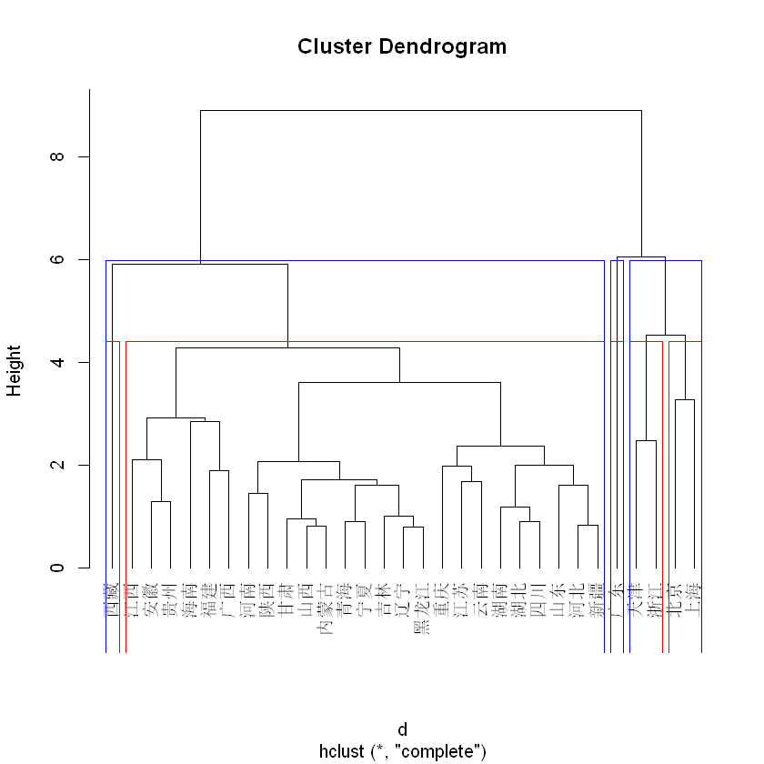

```r
# 使用归一化的数据进行聚类
d <- dist(scale(X_1758))
hc1 <- hclust(d)
plot(hc1, hang=-1)
rect.hclust(hc1, k=5, border='red')
rect.hclust(hc1, k=3, border='blue')
```

```r
# kmeans聚类
library(readr)
eg4_2 <- read_csv("E:\\Project_I\\R\\eg4.2.csv")
head(eg4_2)

name1 <- eg4_2$...1
eg4_2$...1 <- NULL
rownames(eg4_2) <- name1
attributes(eg4_2)

km<-kmeans(scale(eg4_2), 5, nstart = 20, algorithm = 'Hartigan-Wong')
km
sort(km$cluster)
```

```
* `` -> ...1
```

A tibble: 6 × 9

| ...1 <chr> | x1 <dbl> | x2 <dbl> | x3 <dbl> | x4 <dbl> | x5 <dbl> | x6 <dbl> | x7 <dbl> | x8 <dbl> |
| --- | --- | --- | --- | --- | --- | --- | --- | --- |
| 北京 | 7584.2 | 2425.7 | 10350.2 | 2098.3 | 4489.6 | 3634.6 | 2228.6 | 991.4 |
| 天津 | 7709.9 | 1949.4 | 5237.5 | 1514.0 | 3185.9 | 2096.0 | 1757.1 | 712.6 |
| 河北 | 3515.5 | 1055.3 | 2995.8 | 832.2 | 1807.6 | 1338.6 | 1192.0 | 293.6 |
| 山西 | 3089.4 | 1146.7 | 2297.4 | 672.5 | 1501.4 | 1628.0 | 1102.0 | 291.5 |
| 内蒙古 | 4919.8 | 1759.7 | 2918.9 | 1030.9 | 2569.0 | 2067.1 | 1384.3 | 528.9 |
| 辽宁 | 4858.0 | 1561.6 | 3471.6 | 1028.7 | 2282.0 | 1973.3 | 1522.4 | 502.2 |

```
$names
[1] "x1" "x2" "x3" "x4" "x5" "x6" "x7" "x8"

$row.names
 [1] "北京"   "天津"   "河北"   "山西"   "内蒙古" "辽宁"   "吉林"   "黑龙江"
 [9] "上海"   "江苏"   "浙江"   "安徽"   "福建"   "江西"   "山东"   "河南"
[17] "湖北"   "湖南"   "广东"   "广西"   "海南"   "重庆"   "四川"   "贵州"
[25] "云南"   "西藏"   "陕西"   "甘肃"   "青海"   "宁夏"   "新疆"

$class
[1] "spec_tbl_df" "tbl_df"      "tbl"         "data.frame"

$spec

$problems
<pointer: 0x000000001fc19e00>
```

```
K-means clustering with 5 clusters of sizes 2, 14, 2, 8, 5

Cluster means:
          x1          x2         x3         x4         x5         x6
1  2.3241577  2.04080927  3.3301910  2.5941364  2.5664208  2.9367943
2 -0.5165749 -0.05559817 -0.3929201 -0.2485836 -0.3980062 -0.2813143
3  1.6248282  1.48439404  0.9558891  1.2173105  1.6845690  0.8177463
4 -0.5086988 -1.09220808 -0.5415605 -0.8651841 -0.7491491 -0.7805115
5  0.6807334  0.49312649  0.2522411  0.5557499  0.6126598  0.5346821
           x7         x8
1  2.47638301  2.7963988
2  0.07080847 -0.3622761
3  0.92604176  1.1947831
4 -1.06266121 -0.8242695
5  0.14102431  0.7367316

Clustering vector:
  北京   天津   河北   山西 内蒙古   辽宁   吉林 黑龙江   上海   江苏   浙江
     1      3      2      2      5      5      2      2      1      5      3
  安徽   福建   江西   山东   河南   湖北   湖南   广东   广西   海南   重庆
     4      5      4      2      2      2      2      5      4      4      2
  四川   贵州   云南   西藏   陕西   甘肃   青海   宁夏   新疆
     2      4      4      4      2      4      2      2      2

Within cluster sum of squares by cluster:
[1]  4.522493 10.448877  2.173162  8.904881  7.454889
 (between_SS / total_SS =  86.0 %)

Available components:

[1] "cluster"      "centers"      "totss"        "withinss"     "tot.withinss"
[6] "betweenss"    "size"         "iter"         "ifault"
```

**北京**

1

**上海**

1

**河北**

2

**山西**

2

**吉林**

2

**黑龙江**

2

**山东**

2

**河南**

2

**湖北**

2

**湖南**

2

**重庆**

2

**四川**

2

**陕西**

2

**青海**

2

**宁夏**

2

**新疆**

2

**天津**

3

**浙江**

3

**安徽**

4

**江西**

4

**广西**

4

**海南**

4

**贵州**

4

**云南**

4

**西藏**

4

**甘肃**

4

**内蒙古**

5

**辽宁**

5

**江苏**

5

**福建**

5

**广东**

5

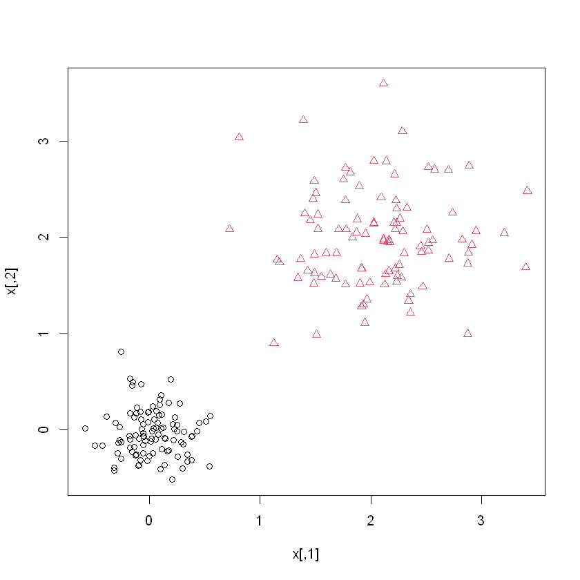

```r
# 展示聚类结果
set.seed(123)
x1 <- matrix(rnorm(1000, 0, 0.25), ncol=10)
x2 <- matrix(rnorm(1000, 2, 0.5), ncol=10)
x <- rbind(x1, x2)
km <- kmeans(x, 2, nstart=20, algorithm="Hartigan-Wong")
plot(x, pch=km$cluster, col=km$cluster)
```

## 6. 判别分析

### 6.1 分类问题

> 这部分会介绍分类问题的一些内容，进行分类的方法有逻辑斯蒂回归、判别分析、贝叶斯判别、KNN等方法

对于常见的几种分类方式，基本的想法是我们已知每个水平的分布，计算每个或个别水平的概率就可以比较出最优可能的一种情况。其中逻辑斯蒂回归是计算其中一种水平的可能，如果>.5就判给这一水平(这一点与贝叶斯判别不同)，所以它对于多水平的判断效果不是很好；判别分析是构建等可能线，判别分析与贝叶斯判别都添加了先验概率的存在，此时对于后验概率的判别就从$\frac{f_k(x)}{\sum f_i(x)}$变成$\frac{\pi_kf_k(x)}{\sum \pi_if_i(x)}$。  
这些方法有一个无法解决的问题:我们把预测数据判给后验概率大的水平，但是忽略了小概率事件发生的可能性，所以这些方法的准确性是有上限的，上限就是发生小概率事件的可能性。  
**结果展示:**  
分类的结果往往通过列联表展示

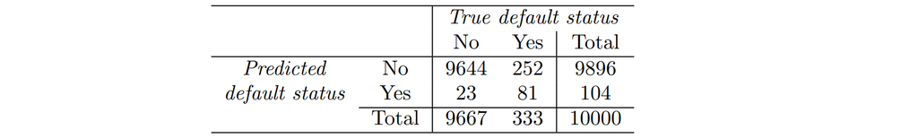

**总体错误率与灵敏度的权衡:**  
在这张表中我们定义两种错误:一个是将违约的人误分类为未违约，一个是将未违约的人误分类为违约。相应的，我们把正确识别违约的人成为灵敏度，正确识别未违约人的概率称为特异度。可以发现上面的模型灵敏度较低，特异度较高，但考虑到问题是关于是否可以放贷的判别，如此低的灵敏度就难以接受了，为了改变这种情况，我们降低了判定为违约者的概率，即我们原来区分是否违约的条件是概率更大，分界线是.5，现在我们降低这个概率，假如我们认为违约概率在.2以上就判给违约，这样结果如下：

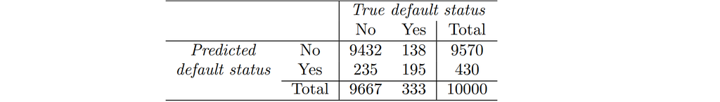

可以看到灵敏度显著提高，但随之整体的错误率也提高了，但是这些是可以接受的。另外有的时候我们担心的是"假阳性率"过高，也就是将没有违约的判为违约，可能就要提高判断为违约的概率，但是无论如何，在分界线为.5的时候总体错误率最低，其他方法都会增加错误率，同样涉及这种权衡的还有变量数选择、模型灵活度等。  
**混淆现象:**  
我们考虑两个模型："是否违约~是否为学生"，"是否违约~收入+贷款金额+是否为学生"，其中第一个模型显示是否为学生呈显著正相关，而第二个模型显示学生呈负相关，并且相同信用额度下学生的贷款违约率显示一直低于非学生的违约率，但是学生总体违约率高于非学生违约率。另外我们发现学生的信用额度是整体高于非学生的，所以我们可以认为学生倾向于持有更高的信用额度，而高信用额度导致了违约。这里我们第一个模型得到的结果虽然结果某种程度是符合数据本身的情况的，但很明显可能导致错误的解读。

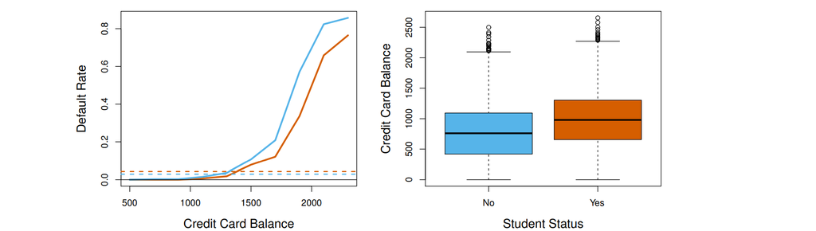

### 6.3 判别分析

判别分析与贝叶斯判别假设总体服从正态分布，结合概率公式$\frac{\pi_kf_k(x)}{\sum \pi_if_i(x)}$，将$f_k(x)$替换为正态分布函数$f_k(x)=\frac{1}{\sqrt{2\pi}\sigma}exp\Big(-\frac{1}{2\sigma_k^2}(x-\mu_k)^2\Big)$，再对两侧取对数就可以得到线性判别分析的结果，二次判别分析则是认为不同总体的协方差不同，但是这里区分线性和二次主要是看灵活度的改变，而不是协方差是否相同。
二次判别又成为"距离判别"，距离判别可以理解为观测到两个类别中心的距离相减，确定判给某个类别，这里使用的是马氏距离。 $$d(x,y)=\sqrt{(x-y)^I\Sigma^{-1}(x-y)}, d^2(x,\mu_2)-d^2(x,\mu_1)=2(x-\bar \mu)^T\Sigma^{-1}(\mu_1-\mu_2)=2a^T(x-\bar\mu)=2W(x)$$ 其中$W(x)$为判别函数，a为判别系数，对于两个总体的距离判别: $$\hat\Sigma=\frac{1}{n_1+n_2-2}(S_1+S_2), W^*=d^2(x,\mu_2)-d^2(x,\mu_1)$$

```r
# 调数据包
library(MASS)
data("iris")
attach(iris)
```

```r
# 建模与解释
iris.lda <- lda(Species~Sepal.Length+Sepal.Width+Petal.Length+Petal.Width)
iris.lda
# Group means: 包含了每组的平均向量
# Coefficients of linear discriminants: 线性判别系数
# Proportion of trace: 表明了第i判别式对区分各组的贡献大小
```

```
Call:
lda(Species ~ Sepal.Length + Sepal.Width + Petal.Length + Petal.Width)

Prior probabilities of groups:
    setosa versicolor  virginica
 0.3333333  0.3333333  0.3333333

Group means:
           Sepal.Length Sepal.Width Petal.Length Petal.Width
setosa            5.006       3.428        1.462       0.246
versicolor        5.936       2.770        4.260       1.326
virginica         6.588       2.974        5.552       2.026

Coefficients of linear discriminants:
                    LD1         LD2
Sepal.Length  0.8293776  0.02410215
Sepal.Width   1.5344731  2.16452123
Petal.Length -2.2012117 -0.93192121
Petal.Width  -2.8104603  2.83918785

Proportion of trace:
   LD1    LD2
0.9912 0.0088
```

```r
# 预测结果展示
# 表示预测的结果判给哪一水平
predict(iris.lda)$class[1:10]
# 得到的对每种水平的概率
head(predict(iris.lda)$posterior)
# 每个观测判别式的结果
head(predict(iris.lda)$x)
```

1. setosa

2. setosa

3. setosa

4. setosa

5. setosa

6. setosa

7. setosa

8. setosa

9. setosa

10. setosa

**Levels**:**

1. 'setosa'

2. 'versicolor'

3. 'virginica'

A matrix: 6 × 3 of type dbl

|  | setosa | versicolor | virginica |
| --- | --- | --- | --- |
| 1 | 1 | 3.896358e-22 | 2.611168e-42 |
| 2 | 1 | 7.217970e-18 | 5.042143e-37 |
| 3 | 1 | 1.463849e-19 | 4.675932e-39 |
| 4 | 1 | 1.268536e-16 | 3.566610e-35 |
| 5 | 1 | 1.637387e-22 | 1.082605e-42 |
| 6 | 1 | 3.883282e-21 | 4.566540e-40 |

A matrix: 6 × 2 of type dbl

|  | LD1 | LD2 |
| --- | --- | --- |
| 1 | 8.061800 | 0.3004206 |
| 2 | 7.128688 | -0.7866604 |
| 3 | 7.489828 | -0.2653845 |
| 4 | 6.813201 | -0.6706311 |
| 5 | 8.132309 | 0.5144625 |
| 6 | 7.701947 | 1.4617210 |

```r
# 使用列联表预测结果展示
iris.pred = predict(iris.lda)$class
table(iris.pred, Species)
```

```
            Species
iris.pred    setosa versicolor virginica
  setosa         50          0         0
  versicolor      0         48         1
  virginica       0          2        49
```

```r
# 预测新的数据点(注意数据框定义)
predict.lda <- data.frame(Sepal.Length=c(5.1, 5.9, 6.6), Sepal.Width=c(3.5, 2.8, 2.9),
                          Petal.Length=c(1.5, 4.3, 5.6), Petal.Width=c(0.25, 1.3, 2.1))
iris.test <- predict(iris.lda, predict.lda)
iris.test
```

**$class**

1. setosa

2. versicolor

3. virginica

**Levels**:**

1. 'setosa'

2. 'versicolor'

3. 'virginica'

**$posterior**

A matrix: 3 × 3 of type dbl

|  | setosa | versicolor | virginica |
| --- | --- | --- | --- |
| 1 | 1.000000e+00 | 1.117074e-20 | 3.314219e-40 |
| 2 | 2.963609e-20 | 9.998273e-01 | 1.727265e-04 |
| 3 | 4.169387e-42 | 3.505610e-05 | 9.999649e-01 |

**$x**

A matrix: 3 × 2 of type dbl

|  | LD1 | LD2 |
| --- | --- | --- |
| 1 | 7.701156 | 0.3491879 |
| 2 | -1.823849 | -0.7749274 |
| 3 | -6.199781 | 0.5182489 |

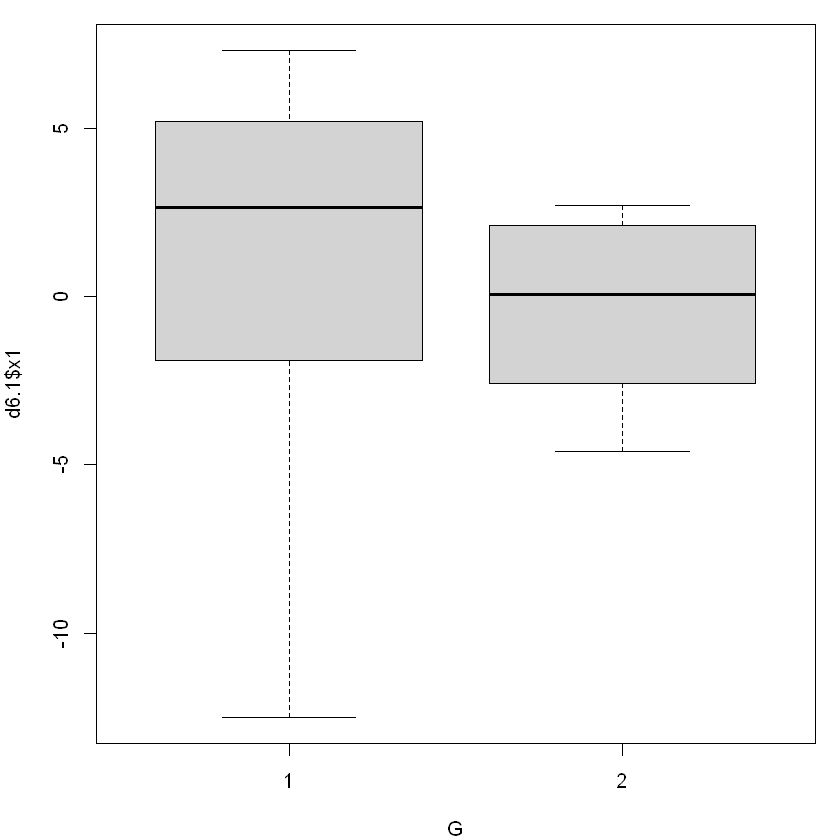

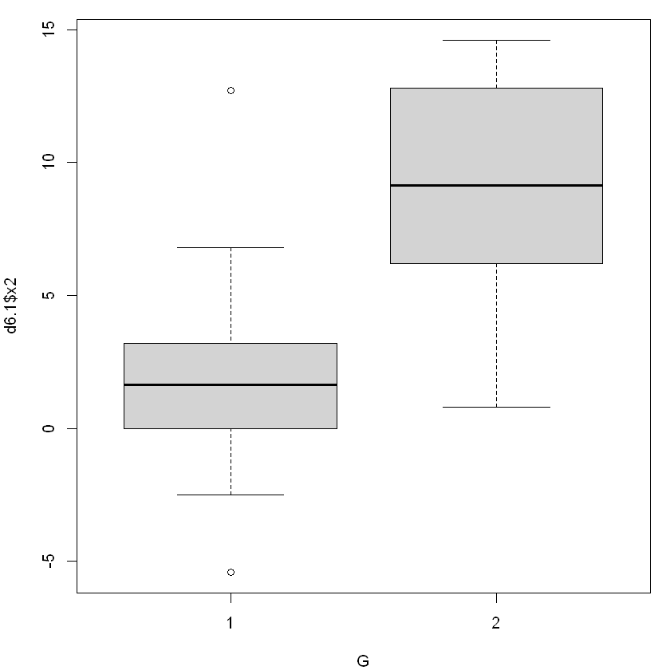

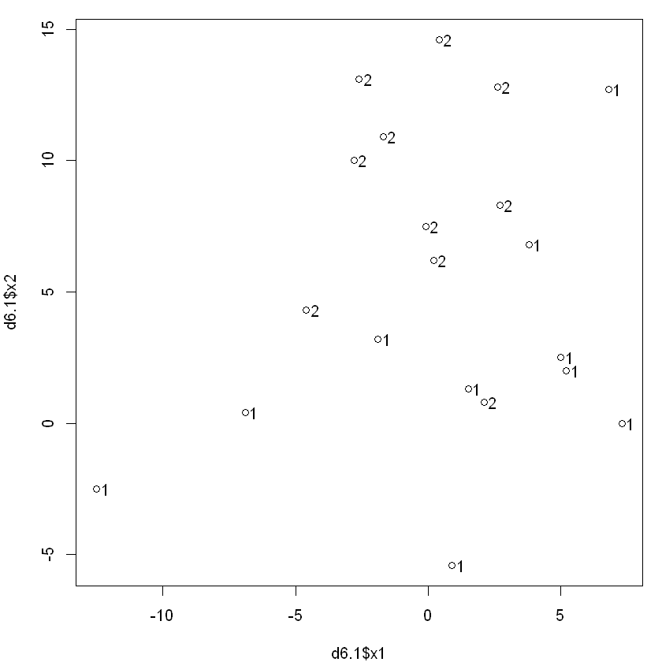

```r
# 数据预分析
library(openxlsx)
par(mar=c(4, 4, 1, 1))
d6.1 <- read.xlsx('E:\\Project_I\\R\\mvstats5.xlsx', 'd6.1')
# 查看不同类型的观测在x1和x2两个维度上有没有差别
# 这里可以进行t检验
boxplot(d6.1$x1~G, d6.1)
boxplot(d6.1$x2~G, d6.1)
# 绘制散点图查看分布
plot(d6.1$x1, d6.1$x2)
text(d6.1$x1, d6.1$x2, d6.1$G, adj=-0.5)
```

```r
# t检验
# 因为判别分析是从定量数据到定性数据，所以可以结合定量和定性数据进行分析
t.test(x1~G, d6.1)
t.test(x2~G, d6.1)
```

```
	Welch Two Sample t-test

data:  x1 by G
t = 0.59897, df = 11.671, p-value = 0.5606
alternative hypothesis: true difference in means between group 1 and group 2 is not equal to 0
95 percent confidence interval:
 -3.443696  6.043696
sample estimates:
mean in group 1 mean in group 2
           0.92           -0.38
```

```
	Welch Two Sample t-test

data:  x2 by G
t = -3.2506, df = 17.655, p-value = 0.004527
alternative hypothesis: true difference in means between group 1 and group 2 is not equal to 0
95 percent confidence interval:
 -11.118792  -2.381208
sample estimates:
mean in group 1 mean in group 2
           2.10            8.85
```

```r
# 组成预测变量
ld <- lda(G~x1+x2, data=d6.1)
testld <- predict(ld)
head(cbind(d6.1$G, testld$x, testld$class))
```

A matrix: 6 × 3 of type dbl

|  |  | LD1 |  |
| --- | --- | --- | --- |
| 1 | 1 | -0.2867490 | 1 |
| 2 | 1 | -0.3985244 | 1 |
| 3 | 1 | -1.2915705 | 1 |
| 4 | 1 | -1.1584666 | 1 |
| 5 | 1 | -1.9585760 | 1 |
| 6 | 1 | 0.9480947 | 2 |

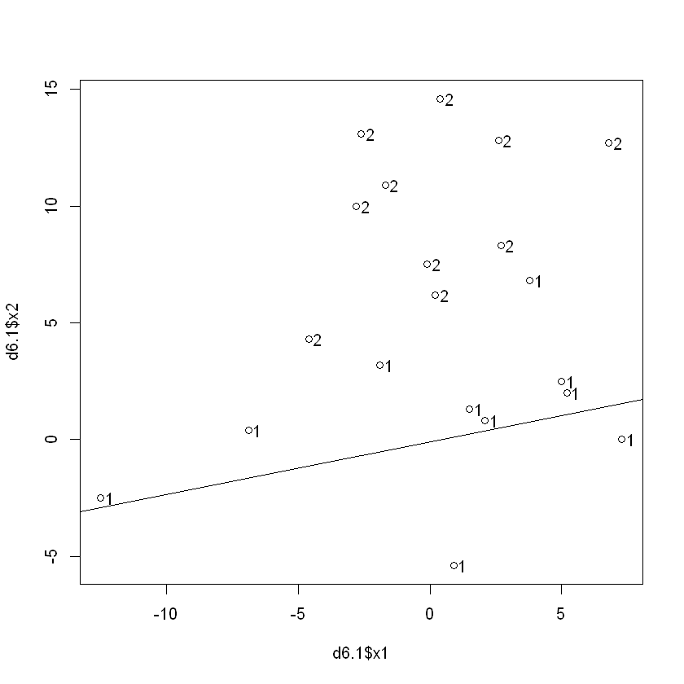

```r
# 查看拟合后的数据分布
plot(d6.1$x1, d6.1$x2)
text(d6.1$x1, d6.1$x2, testld$class, adj=-0.5)
abline(ld)
```

```r
# 对列联表的进一步挖掘
tab <- table(d6.1$G, testld$class)
tab
# 表示整体预测精度
sum(diag(prop.table(tab)))
```

```
    1 2
  1 9 1
  2 1 9
```

0.9

```r
# 使用同协方差进行距离判别
W2equal <- function(x, mu1, mu2, S){(mahalanobis(x, mu2, S) - mahalanobis(x, mu1, S)) / 2}

mu1 <- c(6, 5)
mu2 <- c(8, 6)
S <- matrix(c(9, 2, 2, 4), nrow=2)
x <- c(7.2, 5.6)

W2equal(x, mu1, mu2, S)
```

-0.053125

```r
# 使用不同协方差进行距离判别
W2unequal <- function(x, mu1, mu2, S1, S2){mahalanobis(x, mu2, S2) - mahalanobis(x, mu1, S1)}

mu1 <- c(6, 5)
mu2 <- c(8, 6)
S1 <- matrix(c(9, 2, 2, 4), nrow=2)
S2 <- matrix(c(6, 2, 2, 3), nrow=2)
x <- c(7.2, 5.6)

W2unequal(x, mu1, mu2, S1, S2)
```

-0.0769642857142857

```r
# 使用二次判别函数计算
qd=qda(G~x1+x2, d6.1)
qd
```

```
Call:
qda(G ~ x1 + x2, data = d6.1)

Prior probabilities of groups:
  1   2
0.5 0.5

Group means:
     x1   x2
1  0.92 2.10
2 -0.38 8.85
```

```r
# 使用贝叶斯判别，加入先验概率
d6.3 <- read.xlsx('E:\\Project_I\\R\\mvstats5.xlsx', 'd6.3')
ld1 <- lda(G3~Q+C+P, prior=c(5,8,7)/20, data=d6.3)
ld1
```

```
Call:
lda(G3 ~ Q + C + P, data = d6.3, prior = c(5, 8, 7)/20)

Prior probabilities of groups:
   1    2    3
0.25 0.40 0.35

Group means:
         Q        C      P
1 8.400000 5.900000 48.200
2 7.712500 7.250000 69.875
3 5.957143 3.714286 34.000

Coefficients of linear discriminants:
          LD1         LD2
Q -0.81173396  0.88406311
C -0.63090549  0.20134565
P  0.01579385 -0.08775636

Proportion of trace:
   LD1    LD2
0.7403 0.2597
```

## 7.主成分与因子分析

### 7.1 主成分分析(PCA)

数据降维就是在最大可能保存信息的情况下忽略掉存储信息较少的维度，为了达到这个目的，我们需要重新构建一组相互正交的坐标，这组坐标满足每个维度依次是不考虑前面维度时数据方差最大的方向，这样最大的方差就在坐标轴上，我们可以把末尾拥有最少方差的几个维度删掉。  
为了达到上述的目的，我们先对数据进行标准化，之后构建数据的协方差矩阵，求出协方差矩阵的特征值与特征向量，其中特征值越大意味着该维度具有的方差越大，利用特征向量构建坐标轴转换的公式。在实际使用过程中也常使用相关系数矩阵代替协方差矩阵。  
之后我们计算累计方差贡献率，一般认为贡献率>80%即可。然后可以计算观测的主成分得分，然后使用贡献率加权各项得分计算出观测的综合评价函数$C=\frac{\lambda_1C_1+...+\lambda_nC_n}{\lambda_1+...+\lambda_n}=\sum_{i=1}^n\omega_iC_i$，从而得到得分名次。

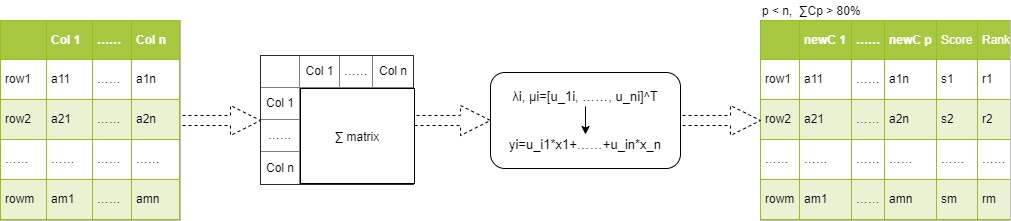

```r
# 导入数据
library(openxlsx)
d3.1 <- read.xlsx("E:\\Project_I\\R\\mvstats5.xlsx", 'd3.1', rowNames=T)
head(d3.1)
```

A data.frame: 6 × 8

|  | 食品 <dbl> | 衣着 <dbl> | 设备 <dbl> | 医疗 <dbl> | 交通 <dbl> | 教育 <dbl> | 居住 <dbl> | 杂项 <dbl> |
| --- | --- | --- | --- | --- | --- | --- | --- | --- |
| 北京 | 4934.05 | 1512.88 | 981.13 | 1294.07 | 2328.51 | 2383.96 | 1246.19 | 649.66 |
| 天津 | 4249.31 | 1024.15 | 760.56 | 1163.98 | 1309.94 | 1639.83 | 1417.45 | 463.64 |
| 河北 | 2789.85 | 975.94 | 546.75 | 833.51 | 1010.51 | 895.06 | 917.19 | 266.16 |
| 山西 | 2600.37 | 1064.61 | 477.74 | 640.22 | 1027.99 | 1054.05 | 991.77 | 245.07 |
| 内蒙古 | 2824.89 | 1396.86 | 561.71 | 719.13 | 1123.82 | 1245.09 | 941.79 | 468.17 |
| 辽宁 | 3560.21 | 1017.65 | 439.28 | 879.08 | 1033.36 | 1052.94 | 1047.04 | 400.16 |

```r
# 进行主成分分析

# cor=TRUE表示用样本相关系数矩阵代替协方差矩阵作主成分分析
# scores=T表示是否计算主成分得分
ddd <- princomp(d3.1, scores=T, cor=T)
names(ddd)
# princomp函数输出有主成份的sd,loading,score,center,scale
# Proportion of Variance表示该维度的方差贡献率，Cp表示累计方差贡献率

# loadings=T表示展示主成分载荷
summary(ddd, loadings=T)
```

1. 'sdev'

2. 'loadings'

3. 'center'

4. 'scale'

5. 'n.obs'

6. 'scores'

7. 'call'

```
Importance of components:
                         Comp.1    Comp.2     Comp.3     Comp.4     Comp.5
Standard deviation     2.387712 1.0142326 0.71012939 0.52226971 0.43144321
Proportion of Variance 0.712646 0.1285835 0.06303547 0.03409571 0.02326791
Cumulative Proportion  0.712646 0.8412295 0.90426494 0.93836065 0.96162855
                           Comp.6     Comp.7      Comp.8
Standard deviation     0.40159675 0.29554587 0.241545582
Proportion of Variance 0.02015999 0.01091842 0.007293034
Cumulative Proportion  0.98178855 0.99270697 1.000000000

Loadings:
     Comp.1 Comp.2 Comp.3 Comp.4 Comp.5 Comp.6 Comp.7 Comp.8
食品  0.353  0.429  0.175  0.299         0.377  0.651
衣着  0.249 -0.677  0.521        -0.399  0.129  0.134
设备  0.374               -0.789  0.261         0.116  0.372
医疗  0.302 -0.472 -0.628  0.225  0.249  0.416
交通  0.376  0.324  0.123  0.127 -0.281  0.267 -0.695  0.298
教育  0.404               -0.200  0.132        -0.156 -0.857
居住  0.371        -0.442        -0.584 -0.535  0.166
杂项  0.374 -0.118  0.282  0.409  0.522 -0.546         0.141
```

```r
# 整合各项得分和排名
# 这里选择前两列是因为前两列累计方差贡献率已经>80%
A <- round(ddd$scores[, 1:2], 3)
# 这里crossprod实际是算平方和
B <- round(apply(A[, 1:2], 1, crossprod), 2)
head(cbind(A, '得分'=B, '排名'=rank(-B)))
```

A matrix: 6 × 4 of type dbl

|  | Comp.1 | Comp.2 | 得分 | 排名 |
| --- | --- | --- | --- | --- |
| 北京 | 6.122 | -1.523 | 39.80 | 2 |
| 天津 | 3.010 | -0.537 | 9.35 | 5 |
| 河北 | -0.888 | -0.692 | 1.27 | 25 |
| 山西 | -1.104 | -0.601 | 1.58 | 22 |
| 内蒙古 | 0.533 | -1.848 | 3.70 | 12 |
| 辽宁 | 0.094 | -0.655 | 0.44 | 29 |

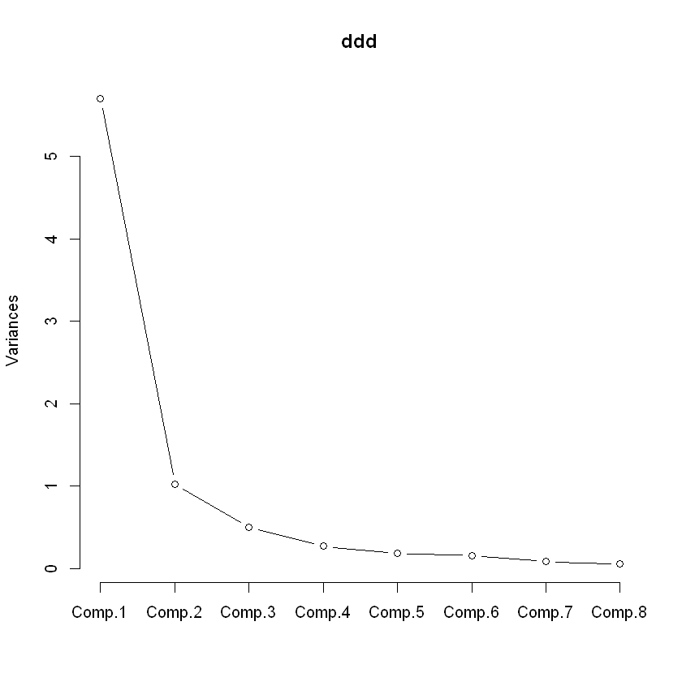

```r
# 绘制滚石图
screeplot(ddd, type=("line"))
```

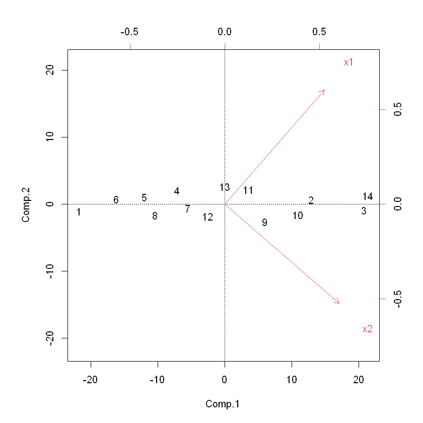

```r
# 绘制坐标转换图
x1 <- c(147, 171, 175, 159, 155, 152, 158, 154, 164, 168, 166, 159, 164, 177)
x2 <- c(32, 57, 64, 41, 38, 35, 44, 41, 54, 57, 49, 47, 46, 63)
X <- cbind(x1, x2)
pc <- princomp(X)
# plot(pc$scores, asp=1)
# abline(h=0, v=0, lty=3)
biplot(pc$scores, pc$loadings)
abline(h=0, v=0, lty=3)
```

### 7.2 因子分析(FA)

> 主要的想法是将相似的变量转换成1个因子，使得因子内部具有高相关性，因子间独立，主要的方法有极大似然估计和主因子法

因子分析可以视为主成分分析的延申，同样可以计算综合得分与排名。  
判断数据是否适合进行因子分析需要进行KMO和Bartlett`s检验，其中KMO得分，0.9非常适合，0.8~0.9适合，0.7~0.8一般，0.6~0.7不太适合，0.5~0.6不适合，<0.5极不适合

```r
# 读取数据
d9.1 = read.xlsx('E:\\Project_I\\R\\mvstats5.xlsx','d9.1', rowNames=TRUE)
cor(d9.1)
```

A matrix: 6 × 6 of type dbl

|  | x1 | x2 | x3 | x4 | x5 | x6 |
| --- | --- | --- | --- | --- | --- | --- |
| x1 | 1.00000000 | 0.9991983 | -0.09974689 | 0.18850763 | 0.2010041 | 0.29778271 |
| x2 | 0.99919830 | 1.0000000 | -0.10420434 | 0.19672979 | 0.1903570 | 0.28747808 |
| x3 | -0.09974689 | -0.1042043 | 1.00000000 | -0.83715637 | -0.4087603 | 0.01518741 |
| x4 | 0.18850763 | 0.1967298 | -0.83715637 | 1.00000000 | 0.2585103 | -0.02928244 |
| x5 | 0.20100410 | 0.1903570 | -0.40876032 | 0.25851029 | 1.0000000 | 0.58029333 |
| x6 | 0.29778271 | 0.2874781 | 0.01518741 | -0.02928244 | 0.5802933 | 1.00000000 |

```r
# 极大似然估计，因子未旋转
# 因子数量需要自己确定
# 确定的原则：逐渐添加因子，直到因子使用的变量重复
Fa1 <- factanal(d9.1, 3, rotation='none')
Fa1
# 下面分别代表：变量的共同度、因子载荷、因子方差贡献率
```

```
Call:
factanal(x = d9.1, factors = 3, rotation = "none")

Uniquenesses:
   x1    x2    x3    x4    x5    x6
0.005 0.005 0.005 0.271 0.005 0.548

Loadings:
   Factor1 Factor2 Factor3
x1  0.950  -0.307
x2  0.948  -0.310
x3 -0.340  -0.782   0.517
x4  0.363   0.561  -0.531
x5  0.454   0.693   0.556
x6  0.383   0.163   0.527

               Factor1 Factor2 Factor3
SS loadings      2.402   1.623   1.140
Proportion Var   0.400   0.271   0.190
Cumulative Var   0.400   0.671   0.861

The degrees of freedom for the model is 0 and the fit was 1.1422
```

```r
# 展示共同度
1 - Fa1$uniquenesses #极大似然法共同度
```

**x1**

0.995

**x2**

0.995

**x3**

0.995

**x4**

0.72879190532854

**x5**

0.995

**x6**

0.451719024209021

```r
# 主因子法
source('E:\\Project_I\\R\\msaR.R')
Fp1 <- msa.fa(d9.1, 3, rotation="none")
Fp1
```

**$vars**

A data.frame: 3 × 3

|  | Variance <dbl> | Proportion <dbl> | Cumulative <dbl> |
| --- | --- | --- | --- |
| Factor1 | 2.570 | 42.83 | 42.83 |
| Factor2 | 1.713 | 28.55 | 71.38 |
| Factor3 | 1.249 | 20.82 | 92.19 |

**$loadings**

A matrix: 6 × 3 of type dbl

|  | Factor1 | Factor2 | Factor3 |
| --- | --- | --- | --- |
| x1 | 0.7829 | 0.5029 | -0.3624 |
| x2 | 0.7811 | 0.4964 | -0.3756 |
| x3 | -0.5786 | 0.7685 | 0.0802 |
| x4 | 0.5951 | -0.6990 | -0.2415 |
| x5 | 0.6317 | -0.1457 | 0.6557 |
| x6 | 0.5084 | 0.3367 | 0.6943 |

**$common**

**x1**

0.9971

**x2**

0.9976

**x3**

0.9318

**x4**

0.9011

**x5**

0.8502

**x6**

0.8539

**$scores**

A matrix: 14 × 3 of type dbl

|  | Factor1 | Factor2 | Factor3 |
| --- | --- | --- | --- |
| 冀东水泥 | 1.1081 | 0.1929 | -0.4023 |
| 大同水泥 | -1.0719 | 1.4639 | -0.3741 |
| 四川双马 | -0.5858 | -0.4985 | 0.2419 |
| 牡丹江 | -1.1744 | -0.7779 | 0.0899 |
| 西水股份 | -0.0526 | -0.4607 | 2.3161 |
| 狮头股份 | -1.0501 | 2.0415 | 0.2517 |
| 太行股份 | 0.2081 | 0.4881 | -0.2343 |
| 海螺水泥 | 2.2075 | 0.3252 | 1.1634 |
| 尖峰集团 | -1.1154 | -1.5323 | 0.3901 |
| 四川金顶 | 0.0971 | -0.6060 | -1.4569 |
| 祁连山 | 0.6610 | 1.0329 | 0.0417 |
| 华新水泥 | 0.4136 | -1.0833 | 0.1980 |
| 福建水泥 | 0.8684 | -0.5325 | -1.8210 |
| 天鹅股份 | -0.5134 | -0.0532 | -0.4042 |

**$ranks**

A data.frame: 14 × 2

|  | Factor <dbl> | Rank <dbl> |
| --- | --- | --- |
| 冀东水泥 | 0.4836 | 3 |
| 大同水泥 | -0.1291 | 8 |
| 四川双马 | -0.3718 | 11 |
| 牡丹江 | -0.7661 | 13 |
| 西水股份 | 0.3559 | 4 |
| 狮头股份 | 0.2013 | 5 |
| 太行股份 | 0.1949 | 6 |
| 海螺水泥 | 1.3888 | 1 |
| 尖峰集团 | -0.9046 | 14 |
| 四川金顶 | -0.4715 | 12 |
| 祁连山 | 0.6363 | 2 |
| 华新水泥 | -0.0987 | 7 |
| 福建水泥 | -0.1728 | 9 |
| 天鹅股份 | -0.3462 | 10 |

```r
# 极大似然估计中的因子旋转
Fa2 = factanal(d9.1,3,rotation='varimax')
# round(Fa1$loadings[1:6,], 4)
Fa2
```

```
Call:
factanal(x = d9.1, factors = 3, rotation = "varimax")

Uniquenesses:
   x1    x2    x3    x4    x5    x6
0.005 0.005 0.005 0.271 0.005 0.548

Loadings:
   Factor1 Factor2 Factor3
x1  0.983           0.155
x2  0.985           0.142
x3         -0.990  -0.124
x4  0.127   0.844
x5          0.293   0.953
x6  0.210           0.631

               Factor1 Factor2 Factor3
SS loadings      1.998   1.800   1.367
Proportion Var   0.333   0.300   0.228
Cumulative Var   0.333   0.633   0.861

The degrees of freedom for the model is 0 and the fit was 1.1422
```

```r
# 主因子法的因子旋转
Fp2 = msa.fa(d9.1, 3 ,rotation='varimax')
Fp2
```

**$vars**

A data.frame: 3 × 3

|  | Variance <dbl> | Proportion <dbl> | Cumulative <dbl> |
| --- | --- | --- | --- |
| Factor1 | 2.014 | 33.56 | 33.56 |
| Factor2 | 1.938 | 32.30 | 65.87 |
| Factor3 | 1.580 | 26.33 | 92.19 |

**$loadings**

A matrix: 6 × 3 of type dbl

|  | Factor1 | Factor2 | Factor3 |
| --- | --- | --- | --- |
| x1 | 0.9867 | 0.0722 | 0.1353 |
| x2 | 0.9881 | 0.0791 | 0.1223 |
| x3 | -0.0095 | -0.9568 | -0.1270 |
| x4 | 0.1353 | 0.9395 | 0.0045 |
| x5 | 0.0441 | 0.3294 | 0.8601 |
| x6 | 0.2085 | -0.1412 | 0.8891 |

**$common**

**x1**

0.9971

**x2**

0.9976

**x3**

0.9318

**x4**

0.9011

**x5**

0.8502

**x6**

0.8539

**$scores**

A matrix: 14 × 3 of type dbl

|  | Factor1 | Factor2 | Factor3 |
| --- | --- | --- | --- |
| 冀东水泥 | 1.0571 | 0.5085 | 0.2254 |
| 大同水泥 | 0.2509 | -1.7047 | -0.6804 |
| 四川双马 | -0.7922 | 0.0524 | -0.1408 |
| 牡丹江 | -1.2794 | -0.0011 | -0.5962 |
| 西水股份 | -1.3825 | -0.0961 | 1.9129 |
| 狮头股份 | 0.2910 | -2.2902 | -0.0628 |
| 太行股份 | 0.5235 | -0.2463 | -0.0410 |
| 海螺水泥 | 1.1476 | 0.6816 | 2.1332 |
| 尖峰集团 | -1.7982 | 0.5941 | -0.3976 |
| 四川金顶 | 0.4175 | 0.8329 | -1.2772 |
| 祁连山 | 1.0061 | -0.5078 | 0.4852 |
| 华新水泥 | -0.4092 | 1.0747 | 0.2476 |
| 福建水泥 | 1.1592 | 1.2532 | -1.1998 |
| 天鹅股份 | -0.1915 | -0.1512 | -0.6085 |

**$ranks**

A data.frame: 14 × 2

|  | Factor <dbl> | Rank <dbl> |
| --- | --- | --- |
| 冀东水泥 | 0.6274 | 2 |
| 大同水泥 | -0.7002 | 13 |
| 四川双马 | -0.3103 | 10 |
| 牡丹江 | -0.6365 | 12 |
| 西水股份 | 0.0093 | 8 |
| 狮头股份 | -0.7144 | 14 |
| 太行股份 | 0.0926 | 6 |
| 海螺水泥 | 1.2658 | 1 |
| 尖峰集团 | -0.5600 | 11 |
| 四川金顶 | 0.0791 | 7 |
| 祁连山 | 0.3269 | 4 |
| 华新水泥 | 0.2983 | 5 |
| 福建水泥 | 0.5185 | 3 |
| 天鹅股份 | -0.2965 | 9 |

```r
# 进行KMO检验
library(psych)
KMO(cor(d9.1))
```

```
Kaiser-Meyer-Olkin factor adequacy
Call: KMO(r = cor(d9.1))
Overall MSA =  0.52
MSA for each item =
  x1   x2   x3   x4   x5   x6
0.52 0.52 0.50 0.53 0.50 0.54
```